# Ingeotec at Rest-Mex: Bag-of-Words Classifiers

IberLEF 2023, September 2023, Jaén, Spain

[Mario Graff](https://mgraffg.github.io)

INFOTEC

[Daniela Moctezuma](https://dmocteo.github.io/)

CentroGEO

[Eric S. Téllez](https://sadit.github.io)

INFOTEC

Sabino Miranda-Jiménez

INFOTEC

## INGEOTEC research group

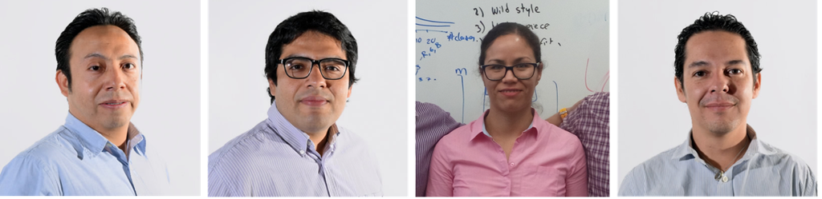

GitHub: https://github.com/INGEOTEC  
WebPage: https://ingeotec.github.io/

# Introduction

**Sentiment analysis** is a powerful tool that can assist businesses and governments in understanding people’s opinions and emotions about various topics.

In the **tourism industry**, Sentiment Analysis can track customer satisfaction, identify trends, and improve marketing campaigns . For example, a tourism business could use Sentiment Analysis to identify which aspects of its products and services are most popular with customers and which areas could be improved or to track the popularity of different destinations, activities, and attractions.

## The Rest-Mex Task at IberLEF 2023

**For the sentiment analysis, the problem is resume as:**

*“Given an opinion about a Mexican tourist place, the goal is to determine the polarity, between 1 and 5, of the text, the type of opinion (hotel, restaurant or attraction) and, the country of the place of which the opinion is being given **(Mexico, Cuba, Colombia)**”*

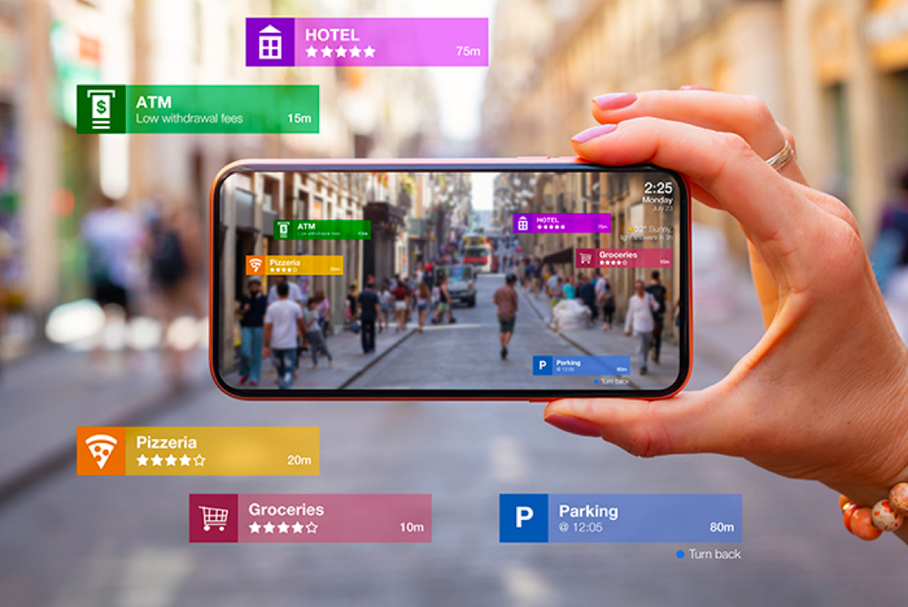

## Our appproach

Our solution system uses **only text-based features**. More particularly, we used our **EvoMSA** framework (Graff et al. 2020).

## Our approach: EvoMSA 2.0

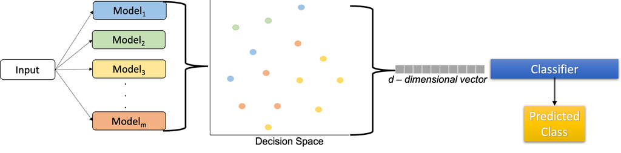

## Our representations

- Sparse bag of words (SBOW)
- Dense bag of words (DBOW)

## Sparse bag of words

The text is preprocessed and tokenized, then each token $t$ is associated with a vector $\mathbf{v_t} \in \mathbb R^d$ where the $i$-th component, i.e., $\mathbf{v_t}_i$, contains the Inverse-Document-Frequency (IDF) value of the token $t$ and $\forall_{j \neq i} \mathbf{v_t}_j=0$.

The set of vectors $\mathbf V = \{ \mathbf v_t \}$ corresponds to the vocabulary, and there are $|\mathbf V| = d$ different tokens in the vocabulary.

A text is represented by the sequence of its tokens, i.e., $(t_1, t_2, \ldots)$. The text is then vectorized as:

$$\textsf{sbow}(\text{some text}) = \textsf{sbow}((t_1, t_2, \ldots)) = \frac{\sum_t \mathbf{v_t}}{\lVert \sum_t \mathbf{v_t} \rVert}$$

## SBoW

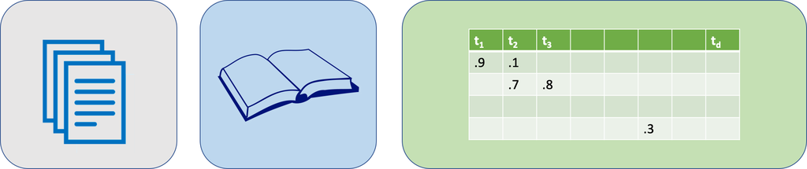

## Dense bag of words

In contrast to SBOW, the dense embeddings come from associating each component to the decision value of a text classifier (e.g., based on SBOW) **pre-trained on a different collection of tweets**.

Without loss of generality, it is assumed that there are $M$ labeled datasets, each one contains a binary text classification problem.

## Construction of the DBOW

For each of these $M$ binary text classification problems, a *SBOW-based* classifier is built using a pre-trained SBOW representation and a linear Support Vector Machine (SVM) as the classifier. Consequently, there are $M$ binary text classifiers, i.e., $(c_1, c_2, \ldots, c_M)$. Additionally, the decision function of $c_i$ is a value where the **sign indicates the class**.  
The text representation is the vector obtained by **concatenating the decision functions** of the $M$ classifiers and then normalizing the vector to have unitary norm.

## Construction (continued…)

A text $x$ is represented with vector $\mathbf{x^{'}} \in \mathbb R^M$ where the value $\mathbf{x^{'}}_i$ corresponds to the decision function of $c_i$. Given that the classifier $c_i$ is a linear SVM, the decision function corresponds to the dot product between the input vector and the weight vector $\mathbf w_i$ plus the bias $\mathbf w_{i_0}$, where the weight vector and the bias are the parameters of the classifier.

## Construction (continued…)

That is, the value $\mathbf{x^{'}}_i$ corresponds to

$$\mathbf{x^{'}}_i = \mathbf w_i \cdot \frac{\sum_t \mathbf{v_t}}{\lVert \sum_k \mathbf{v_k} \rVert} + \mathbf w_{i_0},$$

where $\mathbf{v_t}$ is the IDF vector associated to the token $t$ of the text $x$

## Construction (continued…)

In matrix notation, vector $\mathbf{x'}$ is

$$\mathbf{x^{'}} = \mathbf W \cdot \frac{\sum_t \mathbf{v_t}}{\lVert \sum_k \mathbf{v_k} \rVert} + \mathbf{w_0},$$

where matrix $\mathbf W \in \mathbb R^{M \times d}$ contains the weights, and $\mathbf{w_0} \in \mathbb R^M$ is the bias. Another way to see the previous formulation is by defining a vector $\mathbf{u_t} = \frac{1}{\lVert \mathbf{v_t} \rVert} \mathbf W \mathbf{v_t}$.

## Construction (continued…)

Consequently, $\mathbf{x'}$ is defined as:

$$\label{eq:denseBoW}
\mathbf{x'} = \sum_t \mathbf{u_t} + \mathbf{w_0},$$
vectors $\mathbf{u} \in \mathbb R^M$ correspond to the tokens. *This is the reason we refer to this model as a dense BoW.*

Finally, the vector representing the text $x$ is the normalized $\mathbf{x^{'}}$, i.e., $\mathbf x = \frac{\mathbf{x^{'}}}{\lVert \mathbf{x^{'}} \rVert}.$

## Dense BoW (stacking)

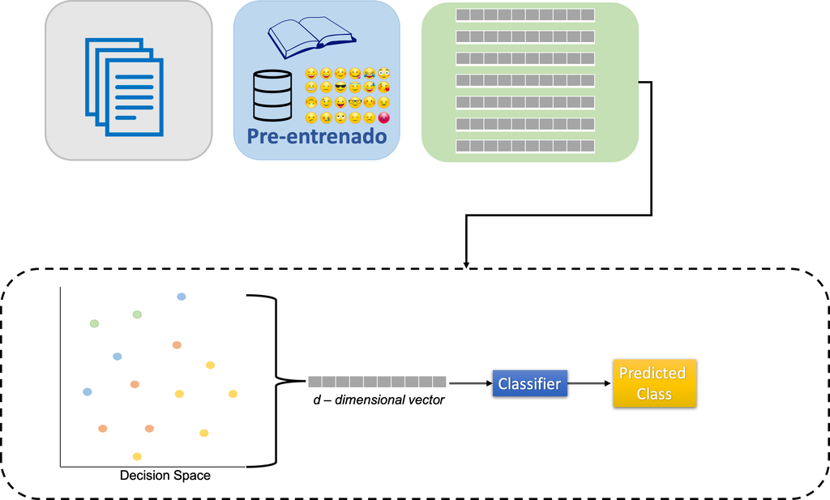

**Stacking**: All models aggregated are used according to their **weights** for producing an output, the **final classification**.

# SBOW parameters

Different BoW representations were created and implemented following the approach described in (Tellez et al. 2017). The first step was to set all the characters to lowercase and remove diacritics and punctuation symbols. Additionally, the users and the URLs were removed from the text. Once the text is normalized, it is split into bigrams, words, and q-grams of characters with $q=\{2, 3, 4\}.$

## SBOW parameters (continued…)

The pre-trained BoW is estimated from 4,194,304 ($2^{22}$) tweets randomly selected in a larger collection of messages.

The IDF values were estimated from the collections, and some tokens were selected from all the available ones found in the collection.

## SBOW parameters (continued…)

Two procedures were used to select the tokens:

1. the first corresponds to selecting the $d$ tokens with the highest frequency, and the other to normalize the frequency w.r.t. their type, i.e., bigrams, words, and q-grams of characters. Once the frequency is normalized, one selects the $d$ tokens with the highest normalized frequency.
2. The value of $d$ is $2^{17}$; however, one can also find in the library models for $2^{13}, 2^{14}, \ldots, 2^{17}.$

## SBOW parameters (continued…)

It is also possible to train the BoW model using the training set; in this case, we used the default parameters. The only difference is that vocabulary size $d$ is bounded by the training set tokens.

# DBOW parameters

The dense representations start by defining the labeled datasets used to create them. These datasets are organized in three groups.

1. A set human-annotated datasets; we refer to them as *dataset*.
2. A set of self-supervised dataset where the objective is to predict the presence of an emoji as expected; these models are referred to as *emoji*.
3. A set of self-supervised datasets where the task is to predict the presence of a particular word, namely *keyword*.

The *keyword* group includes a set of dense representations where the words were selected from the training set; we refer to these representations as *tailored*.

## DBOW parameters (continued…)

Following an equivalent approach used in the development of the pre-trained BoW, different dense representations were created.

These correspond to varying the size of the vocabulary and the two procedures used to select the tokens. Vector spaces:

- *dataset* is in $\mathbb R^{57}$.
- *emoji* is in $\mathbb R^{567}$.
- *keyword* is in $\mathbb R^{2048}$.

# Configurations

We tested 13 different algorithms for each task. The configuration having the best performance was submitted to the contest. The best performance was computed using k-fold cross-validation ($k=5$).

## Configurations (continued…)

The different configurations tested in this competition are described below. These configurations include BoW and a combination of BoW with dense representations. Stack generalization combines the different text classifiers, and the top classifier was a *Naive Bayes algorithm*. The specific implementation of this configuration can be seen in [EvoMSA’s documentation](https://evomsa.readthedocs.io/en/docs/competition.html#davincis).

## Configurations (continued…)

The list of configurations

- `bow`: Pre-trained BoW where the tokens are selected based on a normalized frequency w.r.t. its type, i.e., bigrams, words, and q-grams of characters.
- `bow_voc_selection`: Pre-trained BoW where the tokens correspond to the most frequent ones.
- `bow_training_set`: BoW trained with the training set; the number of tokens corresponds to all the tokens in the set.
- `stack_bow_keywords_emojis`: Stack generalization approach where the base classifiers are the BoW, the *emojis*, and the *keywords* dense BoW.
- `stack_bow_keywords_emojis_voc_selection`: Stack generalization approach where the base classifiers are the BoW, the *emojis*, and the *keywords* dense BoW. The tokens in these models were selected based on a normalized frequency w.r.t. its type, i.e., bigrams, words, and q-grams of characters.

## Configurations (continued…)

- `stack_bows`: Stack generalization approach where the base classifiers are BoW with the two token selection procedures described previously (i.e., `bow` and `bow_voc_selection`).
- `stack_2_bow_keywords`: Stack generalization approach where with four base classifiers. These correspond to two BoW and two dense BoW (*emojis* and *keywords*), where the difference in each is the procedure used to select the tokens, i.e., the most frequent or normalized frequency.
- `stack_2_bow_tailored_keywords`: Stack generalization approach with four base classifiers. These correspond to two BoW and two dense BoW (*emojis* and *keywords*), where the difference in each is the procedure used to select the tokens, i.e., the most frequent or normalized frequency. The second difference is that the dense representation with normalized frequency also includes models for the most discriminant words selected by a BoW classifier in the training set. We refer to these latter representations as *tailored keywords*.

## Configurations (continued…)

- `stack_2_bow_all_keywords`: Stack generalization approach with four base classifiers equivalent to `stack_2_bow_keywords` where the difference is that the dense representations include the models created with the human-annotated datasets.
- `stack_2_bow_tailored_all_keywords`: Stack generalization approach with four base classifiers equivalent to `stack_2_bow_all_keywords`, where the difference is that the dense representation with normalized frequency also includes the tailored keywords.
- `stack_3_bows`: Stack generalization approach with three base classifiers. All of them are BoW; the first two correspond pre-trained BoW with the two token selection procedures described previously (i.e., bow and `bow_voc_selection`), and the latest is a BoW trained on the training set (i.e., `bow_training_set`).

## Configurations (continued…)

- `stack_3_bows_tailored_keywords`: Stack generalization approach with five base classifiers. The first corresponds to a BoW trained on the training set, and the rest are used in `stack_2_bow_tailored_keywords`.
- `stack_3_bow_tailored_all_keywords`: Stack generalization approach with five base classifiers. It is comparable to `stack_3_bows_tailored_keywords` being the difference in the use of the tailored keywords.

# Results

| Configuration | Type | Country | Polarity |
| --- | --- | --- | --- |
| **`bow_training_set`** | **0.9802** | **0.9260** | 0.5179 |
| `bow` | 0.9793 | 0.9194 | 0.5167 |
| `stack_3_bows` | 0.9793 | 0.9225 | 0.5603 |
| `bow_voc_selection` | 0.9792 | 0.9200 | 0.5152 |
| `stack_3_bow_tailored_all_keywords` | 0.9783 | 0.9166 | 0.5467 |
| `stack_3_bows_tailored_keywords` | 0.9783 | 0.9164 | 0.5448 |
| `stack_bows` | 0.9782 | 0.9167 | **0.5605** |
| `stack_2_bow_tailored_keywords` | 0.9773 | 0.9097 | 0.5448 |
| `stack_2_bow_tailored_all_keywords` | 0.9773 | 0.9101 | 0.5446 |
| `stack_2_bow_keywords` | 0.9769 | 0.9076 | 0.5420 |
| `stack_2_bow_all_keywords` | 0.9768 | 0.9076 | 0.5431 |
| `stack_bow_keywords_emojis` | 0.9743 | 0.8951 | 0.5310 |
| `stack_bow_keywords_emojis_voc_selection` | 0.9742 | 0.8949 | 0.5346 |

Performance, in terms of F1, of different configurations on a five fold cross-validation. The best performance is in boldface.

## Competition

Performance comparison of our submission (INGEOTEC) and the competition’s winner. The best performance is in boldface.

|  | Type | Country | Polarity |
| --- | --- | --- | --- |
| Winner | **0.9903** | **0.9420** | 0.6217 |
| INGEOTEC | 0.9805 | 0.9271 | 0.5549 |
| Difference | 1% | 1.6% | 12.0% |

## Other competitions performance

Performance comparison. [EvoMSA’ results](https://evomsa.readthedocs.io/en/docs/competition.html)

| Competition | Winner | EvoMSA 2.0 | Difference |
| --- | --- | --- | --- |
| PoliticEs (Gender) | 0.8296 | 0.7115 | 16.6% |
| **PoliticEs (Profession)** | **0.8608** | **0.8379** | **2.7%** |
| **PoliticEs (Ideology Binary)** | **0.8967** | **0.8913** | **0.6%** |
| **PoliticEs (Ideology Multiclass)** | **0.6913** | **0.6694** | **3.3%** |
| REST-MEX (Polarity) | 0.6216 | 0.5548 | 12.0% |
| **REST-MEX (Type)** | **0.9903** | **0.9805** | **1.0%** |
| **REST-MEX (Country)** | **0.9420** | **0.9270** | **1.6%** |

## Other competitions performance (Continued…)

Performance comparison. [EvoMSA’ results](https://evomsa.readthedocs.io/en/docs/competition.html)

| Competition | Winner | EvoMSA 2.0 | Difference |
| --- | --- | --- | --- |
| HOMO-MEX | 0.8847 | 0.8050 | 9.9% |
| HOPE (ES) | 0.9161 | 0.4198 | 118.2% |
| HOPE (EN) | 0.5012 | 0.4429 | 13.2% |
| DIPROMATS (ES) | 0.8089 | 0.7485 | 8.1% |
| DIPROMATS (EN) | 0.8090 | 0.7255 | 11.5% |
| HUHU | 0.820 | 0.775 | 5.8% |

# Conclusions

We used our EvoMSA framework to merge different internal model outputs to solve the Rest-Mex 2023 challenge; these models are primarily large pre-trained and locally trained vocabularies capturing lexical and semantic features along with linear SVM.

- Our system is based on the ensemble of multiple models using stacked generalization, more precisely with our EvoMSA framework.
- We obtained competitive models compared with more complex and expensive deep learning approaches.
- Our approach uses lexical and semantic features, all computed as bags of words (dense and sparse).
- We achieved an F1 score of **0.9805**, **0.9271**, and **0.5549**, for type, county and polarity, respectively.
- Results with a low difference from 1% to 12% to the winner solution.

## Conclusions (continued…)

[figure not shown]

# Thanks

Questions?

Also, we want to promote the usage of our EvoMSA library.

For EvoMSA documentation see:  
**https://evomsa.readthedocs.io/en/docs/**  
EvoMSA Github repository  
**https://github.com/INGEOTEC/EvoMSA**

# References

Graff, Mario, Sabino Miranda-Jimenez, Eric S Tellez, y Daniela Moctezuma. 2020. «Evomsa: A multilingual evolutionary approach for sentiment analysis [application notes]». *IEEE Computational Intelligence Magazine* 15 (1): 76-88.

Tellez, Eric S., Sabino Miranda-Jiménez, Mario Graff, Daniela Moctezuma, Ranyart R. Suárez, y Oscar S. Siordia. 2017. «A simple approach to multilingual polarity classification in Twitter». *Pattern Recognition Letters* 94: 68-74. https://doi.org/10.1016/j.patrec.2017.05.024.